# FIT3152 Data Analytics: Assignment 2

Dania Ismadi

6/6/2020

# Objective

The objective of this assignment is to gain familiarity with classification models using R. We want to obtain a model that may be used to predict whether it is going to rain tomorrow for 10 locations in Australia.

## Introduction

The following libraries are required for this analysis:

```r
library(tidyr)
library(ggplot2)
library(psych)
library(tree)
library(e1071)
library(ROCR)
library(rpart)
library(adabag)
library(randomForest)
library(neuralnet)
library(dplyr)
library(caret)
library(reshape)
```

The data is read from “WAUS2020.csv” which is a file that contains information like Wind Direction, Pressure, Evaporation, Sunshine, etc. on certain days at certain locations around Australia. Most importantly, each day indicates whether or not it rained the following day. This is the variable we are trying to predict. The following code was run to obtain my personal data sample of 2000 days/rows from 10 different locations in Australia.

```r
rm(list=ls())
WAUS = read.csv("WAUS2020.csv")
L = as.data.frame(c(1:49))
set.seed(30990971)  # Setting my StudentID as the random seed.
L = L[sample(nrow(L), 10, replace=FALSE),]    # Sample 10 locations.
WAUS = WAUS[(WAUS$Location %in% L),]
WAUS = WAUS[sample(nrow(WAUS), 2000, replace=FALSE),]   # Sample 2000 rows.
rownames(WAUS) = NULL
# write.csv(WAUS, file='WAUSsample.csv')
head(WAUS)
```

```
##   Day Month Year Location MinTemp MaxTemp Rainfall Evaporation Sunshine
## 1   4     9 2010       46    15.5    22.1      3.4         1.4      0.1
## 2  17     9 2017       20     1.8    17.8      0.2         3.4     10.9
## 3  18    12 2017       15    20.9    28.5      0.0          NA       NA
## 4  11     8 2010        6     5.3     8.7      6.4          NA       NA
## 5   7     3   NA        6    14.4    23.1     20.0          NA       NA
## 6  16     5 2012       46     8.4    19.6      0.0         2.4      5.0
##   WindGustDir WindGustSpeed WindDir9am WindDir3pm WindSpeed9am WindSpeed3pm
## 1         NNW            52        NNE         NE           22           15
## 2           N            83          N          N           17           37
## 3          NE            28          E         NE            9           20
## 4          SW            76          N        SSW           11           28
## 5         ENE            43          E        NNW           11           19
## 6         WNW            28        WNW          S           20           17
##   Humidity9am Humidity3pm Pressure9am Pressure3pm Cloud9am Cloud3pm Temp9am
## 1          85          84      1015.5      1008.8        8        8    18.6
## 2          58          28      1026.9      1021.4        2        2    10.3
## 3          65          55      1015.8      1012.9       NA       NA    25.8
## 4          99          98      1003.3       998.9        8        8     5.6
## 5          73          85      1012.0      1010.6        7        8    16.8
## 6          67          54      1024.9      1022.6        6        7    13.0
##   Temp3pm RainToday RainTomorrow
## 1    20.3       Yes          Yes
## 2    17.6        No           No
## 3    27.2        No           No
## 4     8.5       Yes          Yes
## 5    18.5       Yes          Yes
## 6    19.3        No           No
```

## Part 1: Exploring the Data

```r
attach(WAUS)
# proportion of rainy days to fine days
# omit empty values
rainy.count = nrow(WAUS[RainTomorrow == "Yes" & !is.na(RainTomorrow),])
fine.count = nrow(WAUS[RainTomorrow == "No" & !is.na(RainTomorrow),])
proportion = rainy.count/fine.count
cat("Proportion of rainy days to fine days: ")
print(proportion)
detach(WAUS)
```

```
## Proportion of rainy days to fine days: [1] 0.2645119
```

```r
describe(WAUS)[-c(1, 2, 3, 4, 10, 12, 13, 24, 25),c(2, 3, 4, 5, 8, 9, 10, 11)]
```

```
##                  n    mean    sd median   min    max range  skew
## MinTemp       1953   11.32  6.06   11.2  -3.6   26.1  29.7 -0.02
## MaxTemp       1967   23.44  6.63   23.0   6.8   45.1  38.3  0.22
## Rainfall      1917    2.16  9.22    0.0   0.0  166.8 166.8 10.90
## Evaporation    501    5.68  4.02    4.8   0.0   21.5  21.5  1.12
## Sunshine       357    7.15  4.02    8.0   0.0   13.7  13.7 -0.39
## WindGustSpeed 1752   40.63 14.12   39.0  11.0  106.0  95.0  0.83
## WindSpeed9am  1944   14.65 10.22   13.0   0.0   74.0  74.0  0.80
## WindSpeed3pm  1889   19.03  9.66   19.0   0.0   59.0  59.0  0.52
## Humidity9am   1936   70.07 18.48   71.0  10.0  100.0  90.0 -0.27
## Humidity3pm   1879   50.46 20.93   50.0   3.0  100.0  97.0  0.24
## Pressure9am   1570 1018.45  6.65 1018.6 999.9 1039.9  40.0 -0.04
## Pressure3pm   1575 1015.94  6.58 1016.0 992.8 1036.0  43.2 -0.04
## Cloud9am       933    4.80  2.93    6.0   0.0    8.0   8.0 -0.39
## Cloud3pm       851    4.94  2.77    6.0   0.0    8.0   8.0 -0.39
## Temp9am       1951   16.79  5.88   16.8   2.5   35.9  33.4  0.02
## Temp3pm       1890   21.90  6.56   21.5   4.7   43.4  38.7  0.27
```

The variable we are trying to predict is represented by the variable, RainTomorrow in the data set. The domain of the column RainTomorrow is {Yes, No}. ‘Yes’ indicates that it will rain tomorrow and ‘No’ indicates that it will not rain tomorrow. With my particular data set, the proportion of rainy days to fine days is 26.45%. This indicates that there are significantly more fine days in comparison to rainy days, thus, the data set is quite inbalanced.

From analysing the numeric predictor variables, we observe that there are a lot of missing values in the data set. For example, the variable Sunshine only has 357 complete observations. This is a problem as it will have an effect on the accuracy of certain models that lack the ability to handle missing values well. In fact, certain models like Random Forest do not accept missing values at all. In order to evaluate the different models fairly and for the sake of consistency, I will only include complete cases and omit all rows with any missing values.

Furthermore, some variables like humidity and the speed of the strongest wind gust have quite high standard deviations. This may have an impact on certain models like the Decision Tree where a small change in the input may lead to drastic changes in the results. However, in this case, this is not a reason to exclude these variables completely from the initial testing of the models. We can see that some of these observations, like Rainfall, Evaporation, Sunshine etc. also contain a large number of values that are 0. I will still include these rows in my analysis because I cannot assume that these values were recorded as 0 because there were no observations for this variable made that day. For example, especially for Rainfall, a value of 0 might represent the fact that there was no rain at all that day. Finally, the level of skew remains low for most variables (except for rainfall). For these reasons as well as the fact that I have no prior information about the context of these variables, I am not justified in removing any of them completely from my analysis. Thus, I will include all variables to build my model. Note that I will include Day, Month, Year and Location as certain times and certain locations might have an effect on the likeliness of it raining tomorrow.

## Part 2: Pre-Processing

To prepare to building the models that follow, my pre-processing includes omitting all missing values and only including complete cases. After this modification, there are 273 complete observations left, which is still a reasonable amount for the models that we will use.

```r
# remove NA values
WAUS = na.omit(WAUS)


# remove rownames
rownames(WAUS) = NULL
```

## Part 3: Creating Training and Test Sets

70% of the data sample is divided into a training set and the remaining 30% is used for the test set.

```r
set.seed(30990971)  # Student ID as the random seed.
train.row = sample(1:nrow(WAUS), 0.7*nrow(WAUS))
WAUS.train = WAUS[train.row,]
WAUS.test = WAUS[-train.row,]
```

## Part 4: Implementing Classification models and Evaluating Accuracy

In this part, we will explore implementing the classification models (Decision Tree, Naive Bayes, Bagging, Boosting and Random Forest) to achieve our objective to predict whether or not it will rain tomorrow. Note that in all the confusion matrices, ‘Will Rain Tomorrow’ is represented as Yes and ‘Will Not Rain Tomorrow’ is represented as No.

### Part 4.1: Decision Tree

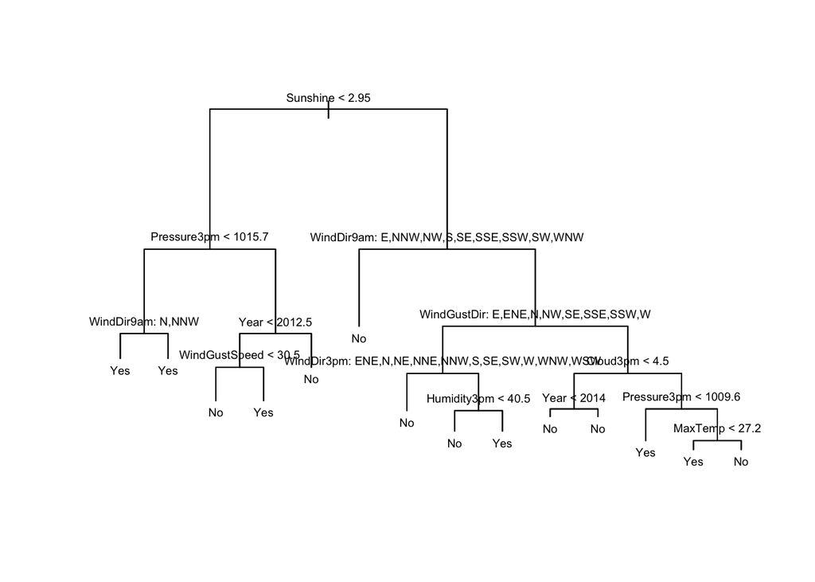

```r
# fit tree model
set.seed(30990971)  # Student ID as the random seed.
WAUS.dtree = tree(RainTomorrow~., data=WAUS.train)
plot(WAUS.dtree)
text(WAUS.dtree, pretty=0, cex=0.6)
```

```r
# predict
# confusion matrix
WAUSdtree.pred = predict(WAUS.dtree, WAUS.test, type="class")
WAUSdtree.matrix = table(`Predicted Class`=WAUSdtree.pred, `Observed Class`=WAUS.test$RainTomorrow)

# accuracy
dtree.accuracy = sum(diag(WAUSdtree.matrix)) / sum(WAUSdtree.matrix)
# precision (TP / TP + FP)
dtree.precision = WAUSdtree.matrix[2,2] / sum(WAUSdtree.matrix[2,])
# recall (TP / TP + FN)
dtree.recall = WAUSdtree.matrix[2,2] / sum(WAUSdtree.matrix[,2])

cat('Confusion Matrix\n')
print(WAUSdtree.matrix)
cat('\nAccuracy: ')
print(dtree.accuracy)
cat('\nPrecision: ')
dtree.precision
cat('\nRecall: ')
dtree.recall
```

```
## Confusion Matrix
##                Observed Class
## Predicted Class No Yes
##             No  53   9
##             Yes 12   8
##
## Accuracy: [1] 0.7439024
##
## Precision: [1] 0.4
##
## Recall: [1] 0.4705882
```

### Part 4.2: Naive Bayes

```r
# fit model
set.seed(30990971)  # Student ID as the random seed.
WAUS.nBayes = naiveBayes(RainTomorrow~., data=WAUS.train)

# test accuracy
WAUSn.predict = predict(WAUS.nBayes, WAUS.test)
WAUSn.matrix = table(`Predicted Class`=WAUSn.predict, `Observed Class`=WAUS.test$RainTomorrow)

# accuracy
nBayes.accuracy = sum(diag(WAUSn.matrix)) / sum(WAUSn.matrix)

# precision (TP / TP + FP)
nBayes.precision = WAUSn.matrix[2,2] / sum(WAUSn.matrix[2,])
# recall (TP / TP + FN)
nBayes.recall = WAUSn.matrix[2,2] / sum(WAUSn.matrix[,2])

cat('Confusion Matrix\n')
print(WAUSn.matrix)
cat('\nAccuracy: ')
print(nBayes.accuracy)
cat('\nPrecision: ')
nBayes.precision
cat('\nRecall: ')
nBayes.recall
```

```
## Confusion Matrix
##                Observed Class
## Predicted Class No Yes
##             No  60   6
##             Yes  5  11
##
## Accuracy: [1] 0.8658537
##
## Precision: [1] 0.6875
##
## Recall: [1] 0.6470588
```

### Part 4.3: Bagging

```r
# fitting the model, number of trees is 100- default value
set.seed(30990971)  # Student ID as the random seed.
# mfinal set to 100 (default value)
WAUS.bag = bagging(RainTomorrow~., data=WAUS.train, mfinal=100)

# testing the model
WAUSbag.pred = predict.bagging(WAUS.bag, newdata=WAUS.test)
WAUSbag.matrix = WAUSbag.pred$confusion

# accuracy
bag.accuracy = sum(diag(WAUSbag.matrix)) / sum(WAUSbag.matrix)
# precision (TP / TP + FP)
bag.precision = WAUSbag.matrix[2,2] / sum(WAUSbag.matrix[2,])
# recall (TP / TP + FN)
bag.recall = WAUSbag.matrix[2,2] / sum(WAUSbag.matrix[,2])

cat('Confusion Matrix\n')
print(WAUSbag.matrix)
cat('\nAccuracy: ')
print(bag.accuracy)
cat('\nPrecision: ')
print(bag.precision)
cat('\nRecall: ')
print(bag.recall)
```

```
## Confusion Matrix
##                Observed Class
## Predicted Class No Yes
##             No  64  12
##             Yes  1   5
##
## Accuracy: [1] 0.8414634
##
## Precision: [1] 0.8333333
##
## Recall: [1] 0.2941176
```

### Part 4.4: Boosting

```r
# fit the model
set.seed(30990971)  # Student ID as the random seed.
# use 100 as the number of trees- default
WAUS.boost = boosting(RainTomorrow~., data=WAUS.train, mfinal=100)

# testing the model
WAUSboost.pred = predict.boosting(WAUS.boost, newdata=WAUS.test)
WAUSboost.matrix = WAUSboost.pred$confusion

# accuracy
boost.accuracy = sum(diag(WAUSboost.matrix)) / sum(WAUSboost.matrix)
# precision (TP / TP + FP)
boost.precision = WAUSboost.matrix[2,2] / sum(WAUSboost.matrix[2,])
# recall (TP / TP + FN)
boost.recall = WAUSboost.matrix[2,2] / sum(WAUSboost.matrix[,2])

cat('Confusion Matrix\n')
print(WAUSboost.matrix)
cat('\nAccuracy: ')
print(boost.accuracy)
cat('\nPrecision: ')
print(boost.precision)
cat('\nRecall: ')
print(boost.recall)
```

```
## Confusion Matrix
##                Observed Class
## Predicted Class No Yes
##             No  64  10
##             Yes  1   7
##
## Accuracy: [1] 0.8658537
##
## Precision: [1] 0.875
##
## Recall: [1] 0.4117647
```

### Part 4.5: Random Forest

```r
# fit the model
set.seed(30990971)  # Student ID as the random seed.
WAUS.rf = randomForest(RainTomorrow~., data=WAUS.train, ntree=500)

# Equalize classes of training and test set, otherwise model will show error when predicting.
# WAUS.test = rbind(WAUS.train[1,], WAUS.test)
# WAUS.test = WAUS.test[-1,]

# testing the model
WAUSrf.pred = predict(WAUS.rf, WAUS.test)
WAUSrf.matrix = table(`Predicted Class`=WAUSrf.pred, `Observed Class`=WAUS.test$RainTomorrow)

# accuracy
rf.accuracy = sum(diag(WAUSrf.matrix)) / sum(WAUSrf.matrix)
# precision (TP / TP + FP)
rf.precision = WAUSrf.matrix[2,2] / sum(WAUSrf.matrix[2,])
# recall (TP / TP + FN)
rf.recall = WAUSrf.matrix[2,2] / sum(WAUSrf.matrix[,2])

cat('Confusion Matrix\n')
print(WAUSrf.matrix)
cat('\nAccuracy: ')
print(rf.accuracy)
cat('\nPrecision: ')
print(rf.precision)
cat('\nRecall: ')
print(rf.recall)
```

```
## Confusion Matrix
##                Observed Class
## Predicted Class No Yes
##             No  65  10
##             Yes  0   7
##
## Accuracy: [1] 0.8780488
##
## Precision: [1] 1
##
## Recall: [1] 0.4117647
```

## Part 5: Constructing ROC Cruves and Calculating AUC

```r
# decision tree
# confidence level- do predictions as probabilities and draw ROC
WAUSdtree.ppred = predict(WAUS.dtree, WAUS.test, type="vector")
cat("\nConfidence Intervals for Decision Trees\n")
head(WAUSdtree.ppred)

# computing a simple ROC curve (y-axis: tpr, x-axis: fpr)
WAUSdpred = ROCR::prediction(as.numeric(WAUSdtree.ppred[,2]), as.numeric(WAUS.test$RainTomorrow))
WAUSdperf = ROCR::performance(WAUSdpred, "tpr", "fpr")

# naive bayes
# confidence level
WAUSn.ppred = predict(WAUS.nBayes, WAUS.test, type='raw')
cat("\nConfidence Intervals for Naive Bayes\n")
head(WAUSn.ppred)

# computing ROC curve and plotting on top of decision tree
WAUSnpred = ROCR::prediction(as.numeric(WAUSn.ppred[,2]), as.numeric(WAUS.test$RainTomorrow))
WAUSnperf = ROCR::performance(WAUSnpred, "tpr", "fpr")

# bagging
# computing ROC curve and plotting on top of decision tree
WAUSbagpred = ROCR::prediction(as.numeric(WAUSbag.pred$prob[,2]), as.numeric(WAUS.test$RainTomorrow))
WAUSbagperf = ROCR::performance(WAUSbagpred, "tpr", "fpr")
cat("\nConfidence Intervals for Bagging\n")
head(WAUSbag.pred$prob)

# boosting
# computing ROC curve
WAUSboostpred = ROCR::prediction(as.numeric(WAUSboost.pred$prob[,2]), as.numeric(WAUS.test$RainTomorrow))
WAUSboostperf = ROCR::performance(WAUSboostpred, "tpr", "fpr")
cat("\nConfidence Intervals for Boosting\n")
head(WAUSboost.pred$prob)

# random forest
# confidence level- do predictions as probabilities and draw ROC
WAUSrf.ppred = predict(WAUS.rf, WAUS.test, type="prob")
cat("\nConfidence Intervals for Random Forest\n")
head(WAUSrf.ppred)

# computing ROC curve
WAUSrfpred = ROCR::prediction(as.numeric(WAUSrf.ppred[,2]), as.numeric(WAUS.test$RainTomorrow))
WAUSrfperf = ROCR::performance(WAUSrfpred, "tpr", "fpr")
```

```
##
## Confidence Intervals for Decision Trees
##           No       Yes
## 11 0.4000000 0.6000000
## 16 1.0000000 0.0000000
## 19 0.4444444 0.5555556
## 20 1.0000000 0.0000000
## 21 0.0000000 1.0000000
## 22 1.0000000 0.0000000
##
## Confidence Intervals for Naive Bayes
##                No          Yes
## [1,] 9.968930e-01 3.106991e-03
## [2,] 9.928718e-01 7.128186e-03
## [3,] 9.996035e-01 3.965104e-04
## [4,] 1.000000e+00 9.814075e-09
## [5,] 1.400154e-01 8.599846e-01
## [6,] 2.378300e-16 1.000000e+00
##
## Confidence Intervals for Bagging
##      [,1] [,2]
## [1,] 0.65 0.35
## [2,] 0.93 0.07
## [3,] 0.99 0.01
## [4,] 0.99 0.01
## [5,] 0.46 0.54
## [6,] 0.99 0.01
##
## Confidence Intervals for Boosting
##           [,1]      [,2]
## [1,] 0.5264533 0.4735467
## [2,] 0.7165440 0.2834560
## [3,] 0.7019921 0.2980079
## [4,] 0.8967681 0.1032319
## [5,] 0.5285388 0.4714612
## [6,] 0.7159986 0.2840014
##
## Confidence Intervals for Random Forest
##       No   Yes
## 11 0.646 0.354
## 16 0.798 0.202
## 19 0.908 0.092
## 20 0.928 0.072
## 21 0.380 0.620
## 22 0.912 0.088
```

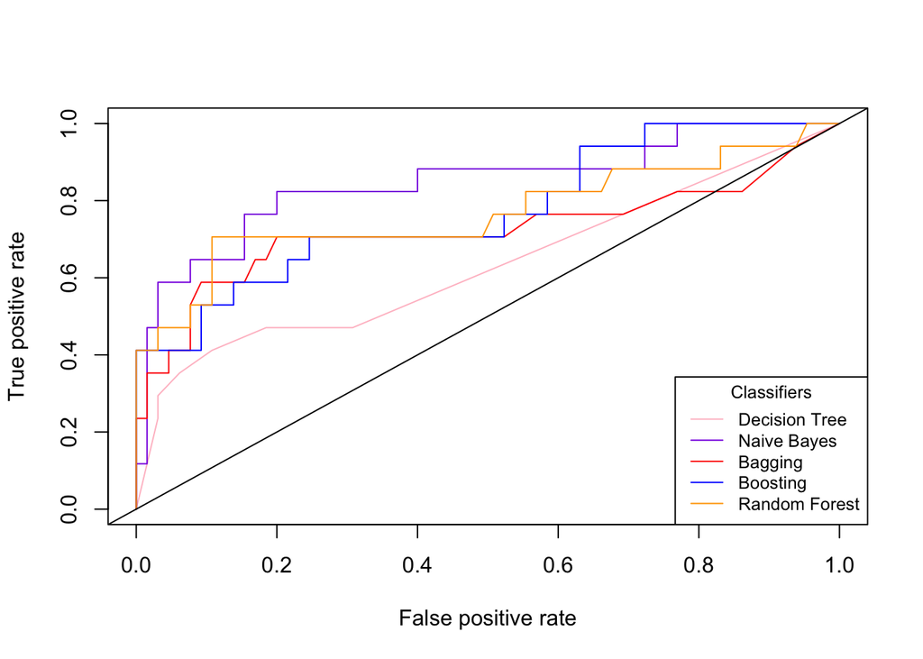

```
##           Model               AUC
## 1 Decision Tree 0.632126696832579
## 2       Bagging  0.72262443438914
## 3 Random Forest 0.768778280542987
## 4      Boosting 0.771945701357466
## 5   Naive Bayes 0.845248868778281
```

```r
# calculate and print auc
# decision tree
dtree.cauc = performance(WAUSdpred, "auc")
dtree.auc = as.numeric(dtree.cauc@y.values)

# naive bayes
n.cauc = performance(WAUSnpred, "auc")
n.auc = as.numeric(n.cauc@y.values)

# bagging
bag.cauc = performance(WAUSbagpred, "auc")
bag.auc = as.numeric(bag.cauc@y.values)

# boosting
boost.cauc = performance(WAUSboostpred, "auc")
boost.auc = as.numeric(boost.cauc@y.values)

# random forest
rf.cauc = performance(WAUSrfpred, "auc")
rf.auc = as.numeric(rf.cauc@y.values)

df = NULL
df = rbind(df, c("Decision Tree", dtree.auc))
df = rbind(df, c("Naive Bayes", n.auc))
df = rbind(df, c("Bagging", bag.auc))
df = rbind(df, c("Boosting", boost.auc))
df = as.data.frame(rbind(df, c("Random Forest", rf.auc)))
colnames(df) = c("Model", "AUC")
attach(df)
df = df[order(AUC),]
rownames(df) = NULL
detach(df)
print(df)

# plotting
plot(WAUSdperf, col="pink")
plot(WAUSnperf, add=TRUE, col="blueviolet")
plot(WAUSbagperf, add=TRUE, col="red")
plot(WAUSboostperf, add=TRUE, col="blue")
plot(WAUSrfperf, add=TRUE, col="orange")
legend("bottomright", legend=c("Decision Tree", "Naive Bayes", "Bagging", "Boosting", "Random Forest"), col=c("pink", "blueviolet", "red", "blue", "orange"), lty=1, cex=0.8, title="Classifiers")
abline(0,1)
```

To construct ROC (Receiver Operating Characteristic) curves, the confidence intervals for each model are calculated. Then, the ROC curves are plotted according to these confidence levels with the True Positive Rate on the y-axis and the False Positive Rate on the x-axis. True Positive Rate is a measure of the ability of the model to correctly predict Yes when it should predict Yes while the False Positive Rate are referred to as false alarms. Thus, the goal for a classifier is to have a low false positive rate and a high true positive rate. However, from the plot above, we can observe that having a high true positive rate will also result in a lot of false alarms which is not desirable. Thus, plotting the ROC curves of each model will help us find a confidence level where there is a healthy balance between the True Positive Rate and the False Positive Rate. ROC curves are also helpful to compare classifiers because given that there is a certain level of confidence we aspire to achieve, ROC curves will help you find the classifier that is more suitable to these conditions and produce the best results. Furthermore, the AUC values, which is the area under the ROC curve, can be calculated to give us a tangible, numerical value to accurately compare the classifiers. A higher AUC value is more desirable than a low one. A further analysis into the comparison between classifiers will be included in part 6.

## Part 6: Comparing Classifiers

```r
classifier = c("Decision Tree", "Naive Bayes", "Bagging", "Boosting", "Random Forest")
accuracy = c(dtree.accuracy, nBayes.accuracy, bag.accuracy, boost.accuracy, rf.accuracy)
auc = c(dtree.auc, n.auc, bag.auc, boost.auc, rf.auc)
precision = c(dtree.precision, nBayes.precision, bag.precision, boost.precision, rf.precision)
recall = c(dtree.recall, nBayes.recall, bag.recall, boost.recall, rf.recall)

compare.classifiers = data.frame("Classifier" = classifier, "Accuracy" = accuracy, "AUC" = auc, "Precision" = precision, "Recall" = recall)

attach(compare.classifiers)
compare.classifiers = compare.classifiers[order(-Accuracy, -AUC, -Precision, -Recall),]
row.names(compare.classifiers) = c(1, 2, 3, 4, 5)
compare.classifiers
```

```
##      Classifier  Accuracy       AUC Precision    Recall
## 1 Random Forest 0.8780488 0.7687783 1.0000000 0.4117647
## 2   Naive Bayes 0.8658537 0.8452489 0.6875000 0.6470588
## 3      Boosting 0.8658537 0.7719457 0.8750000 0.4117647
## 4       Bagging 0.8414634 0.7226244 0.8333333 0.2941176
## 5 Decision Tree 0.7439024 0.6321267 0.4000000 0.4705882
```

```r
detach(compare.classifiers)
```

The idea of a Naive Bayes classification is to maximize the posterior probability (probability of belonging to a class given that a certain set of attributes are true). For a Naive Bayes Model, independence between attributes is assumed. The performance of the Naive Bayes model is very similar to boosting, achieving the same accuracy of 86.59% after predicting 60 No’s and 11 Yes’s correctly out of a total of 82 observations. Precision is lower than other tree-based ensemble classifiers at 69% but Naive Bayes achieves the highest recall of 64.71%. Furthermore, Naive Bayes has the highest AUC value at 84.5%. This is significantly higher (approximately a 7% increase) than the next best AUC value. One reason for the relatively good performance of Naive Bayes might be because it is quite robust to isolated noise points. This suggests that it handles outliers quite well. Thus, since our data contains a few variables with high standard deviations and a high level of skew, this might be a reason as to why Naive Bayes was able to achieve quite a high accuracy. Naive Bayes is also robust to irrelevant attributes. Since I included all the original attributes, this might be another reason why Naive Bayes was able to achieve the level of accuracy as it did as it was able to distinguish between those that are important and those that are not. Nevertheless, we “naively” assumed independence for this model and there are a variety of techniques that we could employ to improve upon it. For example, if the independence assumption does not actually hold, which, for our data set, it certainly does not has variables like Evaporation probably affect other variables like Humidity, we can employ another model called Bayesesian Belief Networks.

## Part 7: Determining Important Variables

```r
# summary(WAUS.dtree)
# WAUS.bag$importance
# WAUS.boost$importance
# WAUS.rf$importance

# find variables used in decision tree
dtree.importance = as.vector(summary(WAUS.dtree)$used)
# dtree.importance

# find important variables used in bagging
bag.importance = as.data.frame(as.table(WAUS.bag$importance))
colnames(bag.importance) = c("Variable", "Bag")
bag.importance = bag.importance[order(bag.importance$`Bag`),]

# find important variables used in boosting
boost.importance = as.data.frame(as.table(WAUS.boost$importance))
colnames(boost.importance) = c("Variable", "Boost")
boost.importance = boost.importance[order(boost.importance$`Boost`),]

# find important variables used in random forest
rf.importance = as.data.frame(as.table(WAUS.rf$importance))
rf.importance[,2] = NULL
colnames(rf.importance) = c("Variable", "Random Forest")
rf.importance = rf.importance[order(rf.importance$`Random Forest`),]

# merge into one data frame
importance = merge(bag.importance, boost.importance)
importance = merge(importance, rf.importance)
importance$`Decision Tree` = ifelse(importance$Variable %in% dtree.importance, 1, 0)

# sort in ascending order based on accuracy of classifier
importance = importance[order(-importance[,4], -importance[,2], -importance[,3], -importance[,5]),]
row.names(importance) = c(1:24)
print(importance)
```

```
##         Variable         Bag      Boost Random Forest Decision Tree
## 1       Sunshine 31.52238815  9.3055603     7.3073189             1
## 2    Humidity3pm 13.20111903  7.7427112     6.6355473             1
## 3     WindDir3pm 11.33935890 17.0668403     6.1123030             1
## 4    WindGustDir 14.16382372 13.3117996     5.3755366             1
## 5     WindDir9am  6.44458118 12.5846093     4.6117818             1
## 6       Cloud3pm  3.98668560  2.1767417     4.3749857             1
## 7    Pressure3pm  6.68113935  4.1030881     3.8352521             1
## 8    Pressure9am  3.17750293  4.2773421     3.4315184             0
## 9  WindGustSpeed  2.54982425  2.8600519     2.3482086             1
## 10       Temp3pm  0.38841829  1.8040360     2.0371134             0
## 11   Humidity9am  0.56799467  2.7386638     2.0297810             0
## 12      Cloud9am  0.22484424  1.5522796     2.0029923             0
## 13       MinTemp  0.61179783  2.2568066     1.9049403             0
## 14       Temp9am  0.78591117  2.2027547     1.8383137             0
## 15       MaxTemp  0.45320304  1.9648286     1.7914346             1
## 16   Evaporation  0.71098597  2.1526436     1.5672194             0
## 17         Month  0.23298169  1.3242725     1.4771256             0
## 18           Day  0.59091490  3.4533526     1.3449799             0
## 19  WindSpeed9am  0.66812941  1.2841346     1.2132444             0
## 20          Year  0.44933471  2.3787903     1.2124926             1
## 21  WindSpeed3pm  0.81455344  1.7339065     1.1093586             0
## 22      Rainfall  0.34011965  1.1199312     1.0500697             0
## 23      Location  0.09438789  0.6048549     0.4720682             0
## 24     RainToday  0.00000000  0.0000000     0.1495030             0
```

For Naive Bayes, it is impossible to analyse the variables that are important in constructing the model which is why it is not included in the data frame above. This is one weakness for Naive Bayes. For the Decision Tree, no rank is assigned to the variables indicating the importance, thus, in the data frame above, the important variables that are used in the construction of the tree are labelled as 1 and those that are not used are labelled as 0. Some of the variables included in the tree construction are Sunshine, Humidity, Wind Direction, and more. The rest of the models use a certain metric to show the importance of an attribute, with higher values corresponding to more relevant attributes and lower values corresponding to less important attributes. Different models may rank the importance of the same variable differently. For example, Sunshine is the most important variable for Bagging and Random Forest but the wind direction at 3pm is the important varaible for Boosting. For all models, we can safely eliminate variables that are 0 or close to 0 in terms of the importance values above. For example, for decision tree, we can safely delete RainToday, Location, Rainfall, WindSpeed3pm, and all others that are labelled as 0 in the data frame above. This is because these variables are not used in the tree construction at all. For the rest of the models, it seems like we can only eliminate RainToday safely and perhaps Location as well. Analysing variable importance can be an important tool for feature selection when attempting to build a better classifier. This technique will be explored in part 8.

## Part 8: Creating an Improved Tree-Based Classifier

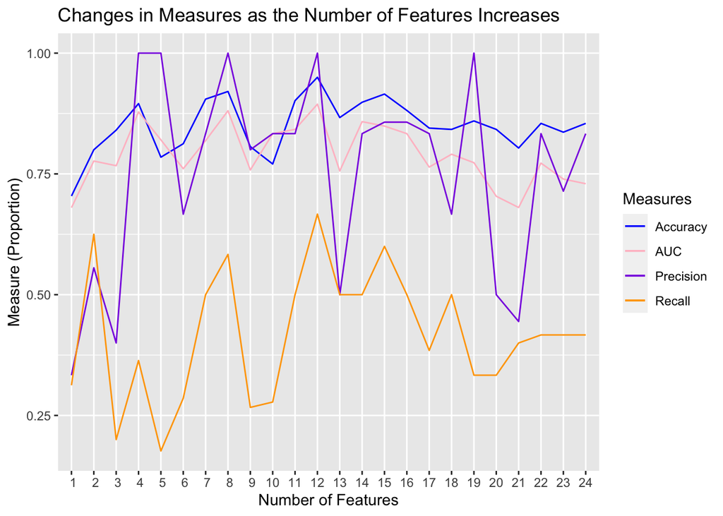

```
##    NumFeatures  Accuracy       AUC Precision    Recall
## 1            1 0.7042254 0.6801136 0.3333333 0.3125000
## 2            2 0.8000000 0.7766204 0.5555556 0.6250000
## 3            3 0.8405797 0.7669492 0.4000000 0.2000000
## 4            4 0.8955224 0.8782468 1.0000000 0.3636364
## 5            5 0.7846154 0.8204657 1.0000000 0.1764706
## 6            6 0.8125000 0.7607143 0.6666667 0.2857143
## 7            7 0.9047619 0.8188679 0.8333333 0.5000000
## 8            8 0.9206349 0.8807190 1.0000000 0.5833333
## 9            9 0.8064516 0.7581560 0.8000000 0.2666667
## 10          10 0.7704918 0.8333333 0.8333333 0.2777778
## 11          11 0.9016393 0.8421569 0.8333333 0.5000000
## 12          12 0.9500000 0.8943355 1.0000000 0.6666667
## 13          13 0.8666667 0.7560096 0.5000000 0.5000000
## 14          14 0.8983051 0.8581633 0.8333333 0.5000000
## 15          15 0.9152542 0.8489796 0.8571429 0.6000000
## 16          16 0.8813559 0.8333333 0.8571429 0.5000000
## 17          17 0.8448276 0.7641026 0.8333333 0.3846154
## 18          18 0.8421053 0.7907407 0.6666667 0.5000000
## 19          19 0.8596491 0.7731481 1.0000000 0.3333333
## 20          20 0.8421053 0.7037037 0.5000000 0.3333333
## 21          21 0.8035714 0.6804348 0.4444444 0.4000000
## 22          22 0.8545455 0.7722868 0.8333333 0.4166667
## 23          23 0.8363636 0.7393411 0.7142857 0.4166667
## 24          24 0.8545455 0.7296512 0.8333333 0.4166667
```

```r
# Use Random Forest

# Reset data frame
WAUS = read.csv("WAUS2020.csv")
L = as.data.frame(c(1:49))
set.seed(30990971)  # Setting my StudentID as the random seed.
L = L[sample(nrow(L), 10, replace=FALSE),]    # Sample 10 locations.
WAUS = WAUS[(WAUS$Location %in% L),]
WAUS = WAUS[sample(nrow(WAUS), 2000, replace=FALSE),]   # Sample 2000 rows.
rownames(WAUS) = NULL

# order important variables in random forest model
rf.importance = rf.importance[order(rf.importance$`Random Forest`, decreasing=TRUE),]

# create data frame to see how many features create the best accuracy
df = NULL
df = data.frame(NumFeatures=c(0), Accuracy=c(0), AUC=c(0), Precision=c(0), Recall = c(0), row.names=NULL)

# start loop
for (i in 1:nrow(rf.importance)) {
  # feature selection
  important.vars = as.vector(rf.importance[1:i,1])
  important.vars = c(important.vars, "RainTomorrow")
  WAUSoriginal = WAUS
  WAUS = select(WAUS, important.vars)
  WAUS = na.omit(WAUS)

  # create training and test sets
  set.seed(9999)
  train.row = sample(1:nrow(WAUS), 0.8*nrow(WAUS))
  WAUS.train = WAUS[train.row,]
  WAUS.test = WAUS[-train.row,]

  # cross validation
  tControl = trainControl(method="repeatedcv", number=10, repeats=3)
  mtry=c(1:length(WAUS))
  rfGrid = expand.grid(.mtry=mtry)
  ntree = 500

  set.seed(30990971)
  WAUS.rf = train(RainTomorrow~., data=WAUS.train, method='rf', metric="Accuracy", tuneGrid = rfGrid, trControl=tControl, ntree=ntree)

  # testing the model
  WAUSrf.pred = predict(WAUS.rf, WAUS.test)
  WAUSrf.matrix = table(actual=WAUS.test$RainTomorrow, predicted=WAUSrf.pred)

  # accuracy
  rf.accuracy = sum(diag(WAUSrf.matrix)) / sum(WAUSrf.matrix)

  # precision (TP / TP + FP)
  rf.precision = WAUSrf.matrix[2,2] / sum(WAUSrf.matrix[,2])

  # recall (TP / TP + FN)
  rf.recall = WAUSrf.matrix[2,2] / sum(WAUSrf.matrix[2,])

  # confidence level- do predictions as probabilities and draw ROC
  WAUSrf.ppred = predict(WAUS.rf, WAUS.test, type="prob")
  # head(WAUSrf.ppred)

  # computing ROC curve and plotting on top of decision tree
  WAUSrfpred = ROCR::prediction(as.numeric(WAUSrf.ppred[,2]), as.numeric(WAUS.test$RainTomorrow))
  WAUSrfperf = ROCR::performance(WAUSrfpred, "tpr", "fpr")

  rf.cauc = performance(WAUSrfpred, "auc")
  rf.auc = as.numeric(rf.cauc@y.values)

  df = rbind(df, c(i, rf.accuracy, rf.auc, rf.precision, rf.recall))
  WAUS = WAUSoriginal
}

df = df[-1,]
rownames(df) = NULL

# plot measures against the number of features
g = ggplot(data=df, aes(x=NumFeatures)) + geom_line(aes(y=Accuracy, colour="Accuracy"))
g = g + geom_line(aes(y=AUC, colour="AUC"))
g = g + geom_line(aes(y=Precision, colour="Precision"))
g = g + geom_line(aes(y=Recall, colour="Recall"))
g = g + scale_colour_manual("Measures", breaks = c("Accuracy", "AUC", "Precision", "Recall"), values=c("blue", "pink", "blueviolet", "orange"))
g = g + ggtitle("Changes in Measures as the Number of Features Increases")
g = g + ylab("Measure (Proportion)")
g = g + xlab("Number of Features")
g = g + scale_x_discrete(limits=c(1:24))

print(df)
print(g)
```

In this part, I explored how to create an improved tree-based classifier through cross validation, parameter tuning and feature selection. Since Random Forest was already a strong tree-based model overall as we have discovered in part 6, I decided to build upon this.

For parameter tuning, I experimented with modifying the mtry parameter in tuneGrid and changing the number of trees. For the tuneGrid parameter in the train function, I set the number of randomly selected predictors (mtry) to be the number of variables used in the model. After having tried many different tree sizes, I found that setting the paramter to 500 trees yielded the best accuracy. This might be because using more trees might have led to overfitting and on the opposite spectrum, using less trees might have led to underfitting.

As for feature selection, I used the analysis we performed for variable importance in part 7. The original Random Forest model was able to rank the variable in order of importance with a metric called the Mean Decrease Gini. A high Mean Decrease Gini measurement corresponded to the variable being of higher importance in the model. To find a good selection of features to include in this improved model, I attempted to fit the model n different times, where n is the total number of variables in the original data set. At each attempt, I included one additional feature and the features were included in order of descending Mean Decrease Gini scores (signalling variable importance) as found in part 7. Thus, the first iteration included the most important variable, the second iteration included the two most important variables, and so on.

From the plot above, we can see how accuracy, AUC, precision and recall changes as we include more and more attributes. There seems to be no direct trend but we can see that a selection of the 12 most important features yields the best results. Referring to the data frame, we see that by including the 12 most important features in our model, we are able to achieve an accuracy of 95%, 100% precision, 66.67% recall and an AUC value of 89.43%. These measurements are significantly better than all the models we have created- approximately 7% increase in accuracy and 4% AUC than the best model measurements in the previous part (and about 12% increase in AUC from the original Random Forest model).

## Part 9: Implementing Artificial Neural Network

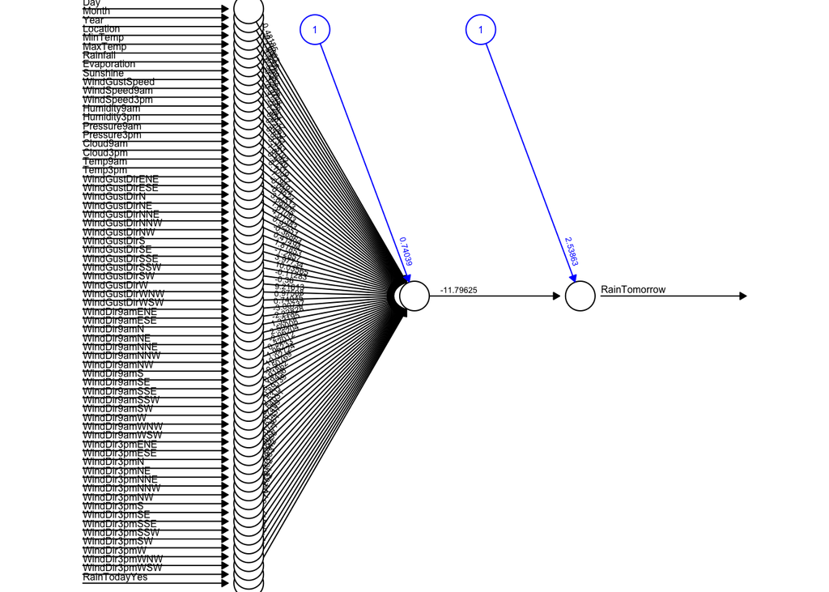

```r
WAUS = read.csv("WAUS2020.csv")
L = as.data.frame(c(1:49))
set.seed(30990971)  # Setting my StudentID as the random seed.
L = L[sample(nrow(L), 10, replace=FALSE),]    # Sample 10 locations.
WAUS = WAUS[(WAUS$Location %in% L),]
WAUS = WAUS[sample(nrow(WAUS), 2000, replace=FALSE),]   # Sample 2000 rows.

# remove NA values
WAUS = na.omit(WAUS)
rownames(WAUS) = NULL

# recode output class as numeric
WAUS = WAUS %>% mutate(RainTomorrow=dplyr::recode(RainTomorrow, "Yes"=1, "No"=0))

WAUSmm = model.matrix(~WindGustDir+WindDir9am+WindDir3pm+RainToday, data=WAUS)
WAUS = cbind(WAUS, WAUSmm)
WAUS$WindGustDir = NULL
WAUS$WindDir9am = NULL
WAUS$WindDir3pm = NULL
WAUS$RainToday = NULL
WAUS$`(Intercept)` = NULL

# scaled normalization
col.num = which(colnames(WAUS)=="RainTomorrow")
scaledWAUS = scale(WAUS[,-c(col.num:length(WAUS))])
scaledWAUS = cbind(scaledWAUS, as.data.frame(WAUS[,c(col.num:length(WAUS))]))

# create training and test sets
set.seed(30990971)
train.row = sample(1:nrow(scaledWAUS), 0.8*nrow(scaledWAUS))
WAUS.train = scaledWAUS[train.row,]
WAUS.test = scaledWAUS[-train.row,]

# fit model
n = names(WAUS.train)
f = as.formula(paste("RainTomorrow ~", paste(n[!n %in% "RainTomorrow"], collapse=" + ")))

set.seed(30990971)
WAUS.nn = neuralnet(f, data=WAUS.train, hidden=1, linear.output=FALSE)

# predict
col.num = which(colnames(WAUS.test)=="RainTomorrow")
WAUS.pred = neuralnet::compute(WAUS.nn, WAUS.test[,-col.num])
results = data.frame(actual=WAUS.test$RainTomorrow, prediction = WAUS.pred$net.result)

# round predictions to 0 or 1
WAUS.predr = sapply(results, round, digits=0)
WAUS.predrdf = data.frame(WAUS.predr)
attach(WAUS.predrdf)
WAUSmatrix = table(actual, prediction)
detach(WAUS.predrdf)

accuracy = sum(diag(WAUSmatrix)) / sum(WAUSmatrix)
# precision (TP / TP + FP)
precision = WAUSmatrix[2, 2] / sum(WAUSmatrix[,2])
# recall (TP / TP + FN)
recall = WAUS[2,2] / sum(WAUSmatrix[2,])

plot(WAUS.nn, cex=0.5, rep="best")
```

```r
cat('\nConfusion matrix\n')
print(WAUSmatrix)
cat('\nAccuracy: ')
print(accuracy)
cat('\nPrecision: ')
print(precision)
cat('\nRecall: ')
print(recall)
```

```
##
## Confusion matrix
##       prediction
## actual  0  1
##      0 38  4
##      1  6  7
##
## Accuracy: [1] 0.8181818
##
## Precision: [1] 0.6363636
##
## Recall: [1] 0.6923077
```

In this part, we explored the use of an artificial neural network to predict whether or not it will rain tomorrow. Pre-processing data is a requirement before implementing an artifical neural network. As with our previous models, all missing values are omitted from the data set. Artificial neural networks requires the data to be numerical, thus, indicator columns were created for each categorical attribute. In order to do this, I used ‘recode’ to convert the output class (RainTomorrow). Yes’s were converted into 1 and No’s were converted into 0. For the other categorical attributes, I used ‘model.matrix’ to convert them into numerical data. Another requirement of artificial neural networks is for the data to be normalised to a common scale. This is achived through the inbuilt ‘scale’ function which scales values by using the mean and standard deviation of the data set. Normalization is important as failure to do so might result in the prediction value remaining the same regardless of input values. Furthermore, I included all the attributes in this model because the previous analysis on variable importance was based on specific classifiers, thus, it is not justified to carry those conclusions to this model. Variables that are not important in those models might be important in this model and vice versa. Finally, I set the hidden layer to 1 because after having tried with up to 20 hidden layers, I observed no difference in the results.

## Conclusion

To summarise, we observed that a basic decision tree yielded the worst accuracy for attempting to predict whether or not it will rain tomorrow in certain locations in Australia based on a set of variables. The most accurate model in terms of accuracy was Random Forest followed by Naive Bayes, Boosting, and then Bagging, in that order. Considering AUC values, Naive Bayes was the best, followed by Boosting, Random Forest, Bagging and then Decision Tree. From examining variable importance, we realise that different models come to different conclusions as to which attributes are the most important, however, we notice that across all models, there seems to be a consensus that RainToday can be eliminated with very little effect on performance. After building upon the random forest model with cross validation, parameter tuning and feature selection, we were able to achieve a significantly higher accuracy of 95% and an AUC value of 89% in comparison to the previous models implemented with default settings. Finally, after implementing an Artificial Neural Network classifier, we concluded that it while it is significantly better than the decision tree model, it is comparable to the other ensemble methods.

## Appendix

### Improving Upon the Bagging Model

```r
# Use Bagging
WAUS = read.csv("WAUS2020.csv")
L = as.data.frame(c(1:49))
set.seed(30990971)  # Setting my StudentID as the random seed.
L = L[sample(nrow(L), 10, replace=FALSE),]    # Sample 10 locations.
WAUS = WAUS[(WAUS$Location %in% L),]
WAUS = WAUS[sample(nrow(WAUS), 2000, replace=FALSE),]   # Sample 2000 rows.
WAUS$Day = NULL
WAUS$Month = NULL
WAUS$Year = NULL
rownames(WAUS) = NULL

# Omit NA Values
WAUS = na.omit(WAUS)

# Create training and test data.
set.seed(30990971)  # Student ID as the random seed.
train.row = sample(1:nrow(WAUS), 0.7*nrow(WAUS))
WAUS.train = WAUS[train.row,]
WAUS.test = WAUS[-train.row,]

# cross validation
tControl = trainControl(method="repeatedcv", number=5, repeats=3)
rfGrid = expand.grid(mfinal=20, maxdepth=25)

set.seed(30990971)
WAUS.rf = train(RainTomorrow~., data=WAUS.train, method='AdaBag', metric="Accuracy", tuneGrid = rfGrid, trControl=tControl)

# testing the model
WAUSrf.pred = predict(WAUS.rf, WAUS.test)
WAUSrf.matrix = table(actual=WAUS.test$RainTomorrow, predicted=WAUSrf.pred)
print(WAUSrf.matrix)

# accuracy
rf.accuracy = sum(diag(WAUSrf.matrix)) / sum(WAUSrf.matrix)

# precision (TP / TP + FP)
rf.precision = WAUSrf.matrix[2,2] / sum(WAUSrf.matrix[,2])

# recall (TP / TP + FN)
rf.recall = WAUSrf.matrix[2,2] / sum(WAUSrf.matrix[2,])

# confidence level- do predictions as probabilities and draw ROC
WAUSrf.ppred = predict(WAUS.rf, WAUS.test, type="prob")
# head(WAUSrf.ppred)

# computing ROC curve and plotting on top of decision tree
WAUSrfpred = ROCR::prediction(as.numeric(WAUSrf.ppred[,2]), as.numeric(WAUS.test$RainTomorrow))
WAUSrfperf = ROCR::performance(WAUSrfpred, "tpr", "fpr")

rf.cauc = performance(WAUSrfpred, "auc")
rf.auc = as.numeric(rf.cauc@y.values)

cat('Confusion Matrix\n')
print(WAUSrf.matrix)
cat('\nAccuracy: ')
print(rf.accuracy)
cat('\nPrecision: ')
print(rf.precision)
cat('\nRecall: ')
print(rf.recall)
cat('\nAUC: ')
print(rf.auc)
```

```
##       predicted
## actual No Yes
##    No  67   2
##    Yes  9   7
## Confusion Matrix
##       predicted
## actual No Yes
##    No  67   2
##    Yes  9   7
##
## Accuracy: [1] 0.8705882
##
## Precision: [1] 0.7777778
##
## Recall: [1] 0.4375
##
## AUC: [1] 0.7848732
```

## Improving Upon the Boosting Model

```r
# Use boosting
WAUS = read.csv("WAUS2020.csv")
L = as.data.frame(c(1:49))
set.seed(30990971)  # Setting my StudentID as the random seed.
L = L[sample(nrow(L), 10, replace=FALSE),]    # Sample 10 locations.
WAUS = WAUS[(WAUS$Location %in% L),]
WAUS = WAUS[sample(nrow(WAUS), 2000, replace=FALSE),]   # Sample 2000 rows.
rownames(WAUS) = NULL

# Omit NA Values
WAUS = na.omit(WAUS)

# Create training and test data.
set.seed(30990971)  # Student ID as the random seed.
train.row = sample(1:nrow(WAUS), 0.7*nrow(WAUS))
WAUS.train = WAUS[train.row,]
WAUS.test = WAUS[-train.row,]

set.seed(30990971)

# Create training and test data.
set.seed(30990971)  # Student ID as the random seed.
train.row = sample(1:nrow(WAUS), 0.7*nrow(WAUS))
WAUS.train = WAUS[train.row,]
WAUS.test = WAUS[-train.row,]

# cross validation
tControl = trainControl(method="repeatedcv", number=5, repeats=3)
rfGrid = expand.grid(mfinal=20, coeflearn="Breiman", maxdepth=20)

set.seed(30990971)
WAUS.rf = train(RainTomorrow~., data=WAUS.train, method='AdaBoost.M1', metric="Accuracy", tuneGrid = rfGrid, trControl=tControl)

# testing the model
WAUSrf.pred = predict(WAUS.rf, WAUS.test)
WAUSrf.matrix = table(actual=WAUS.test$RainTomorrow, predicted=WAUSrf.pred)

# accuracy
rf.accuracy = sum(diag(WAUSrf.matrix)) / sum(WAUSrf.matrix)

# precision (TP / TP + FP)
rf.precision = WAUSrf.matrix[2,2] / sum(WAUSrf.matrix[,2])

# recall (TP / TP + FN)
rf.recall = WAUSrf.matrix[2,2] / sum(WAUSrf.matrix[2,])

# confidence level- do predictions as probabilities and draw ROC
WAUSrf.ppred = predict(WAUS.rf, WAUS.test, type="prob")
# head(WAUSrf.ppred)

# computing ROC curve and plotting on top of decision tree
WAUSrfpred = ROCR::prediction(as.numeric(WAUSrf.ppred[,2]), as.numeric(WAUS.test$RainTomorrow))
WAUSrfperf = ROCR::performance(WAUSrfpred, "tpr", "fpr")

rf.cauc = performance(WAUSrfpred, "auc")
rf.auc = as.numeric(rf.cauc@y.values)

cat('Confusion Matrix\n')
print(WAUSrf.matrix)
cat('\nAccuracy: ')
print(rf.accuracy)
cat('\nPrecision: ')
print(rf.precision)
cat('\nRecall: ')
print(rf.recall)
cat('\nAUC: ')
print(rf.auc)
```

```
## Confusion Matrix
##       predicted
## actual No Yes
##    No  62   3
##    Yes  8   9
##
## Accuracy: [1] 0.8658537
##
## Precision: [1] 0.75
##
## Recall: [1] 0.5294118
##
## AUC: [1] 0.7515837
```